# R Notebook

Based on Allen 2017 paper From README on github: The file data/predictions.RData contains the output of the model. All variables are described in more depth in the paper.

The columns lon and lat are WGS84 longitude and latitude. gridid is a grid cell identifier. + bsm_weight_pubs is the model’s output weighted with publications (“observed”). + bsm_weight_pop is the model’s output weighted with population (“bias factored out”). + bsm_response is the model’s output weighted with neither. The other columns are generally predictor variables used in the model.

I used bsm_response on the data Peter suggested. But it produced figure 4.

However, on the metadata of the file I download bsm_response is described as: https://github.com/ecohealthalliance/hotspots2/blob/a27520e8d6fe1950cb4b88299efcd229e36135b9/inst/out/unbl_data/metadata.csv bsm_response: The binomial probability that a grid cell sampled at that location will contain an EID event as opposed to a background sample, when drawing equal numbers of absence and background samples weighted by reporting effort.

```r
# 1) Download authors' Zenodo archive with data/figures/code
# (Allen et al. 2017 "hotspots2" v1.0r2)
eid_risk_relative_to_reporting_effor <- read_csv("/Anthropocene-maps/6.Infectious_diseases/eid_risk_relative_to_reporting_effor.csv")
```

```
Error:
! /Anthropocene-maps/6.Infectious_diseases/eid_risk_relative_to_reporting_effor.csv does
  not exist.
Run `rlang::last_trace()` to see where the error occurred.
```

# Figure 4

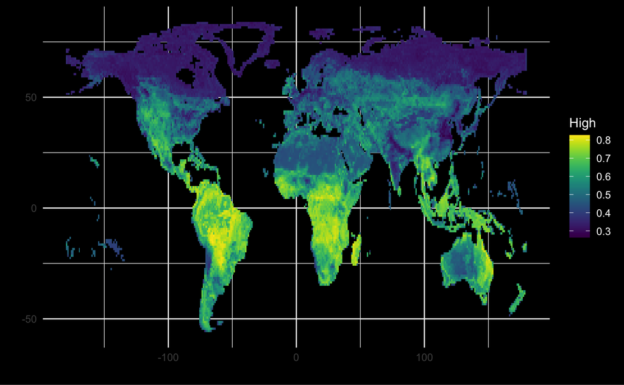

#Figure 4 polished

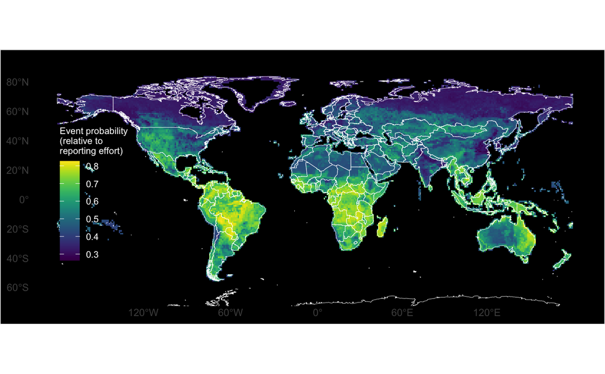

# try to increase resolution

```r
ggplot(data = r_sum_land, aes(x = x, y = y, fill = last)) +
  geom_tile() +
  geom_sf(data = land_sf, fill = NA, color = "lightgray", linewidth = 0.1) +
  coord_sf(crs = st_crs(crs_moll), expand = FALSE) +
#  geom_sf(data =land_sf, fill = NA, color = "white", size = 0.15) +
  #  coord_fixed() +
#  ylim(-65, 90) +
  scale_fill_gradientn(colours = viridis(100),
                       guide = guide_colorbar(label = TRUE,
                                              label.position = "right",
                                              title = "Event probability\n(relative to\nreporting effort)")) +
theme(panel.background = element_rect(fill = "black"),
        plot.background  = element_rect(fill = "black"),
        line = element_blank(),
        legend.title = element_text(color = "white", size = 8),
        legend.text = element_text(color = "white", size = 8),
        legend.title.align = 0,
        legend.background = element_blank(),
        legend.position = c(0.11, 0.45)) +
  labs(x = NULL, y = NULL)
```

```
Error in `geom_sf()`:
! Problem while computing aesthetics.
ℹ Error occurred in the 2nd layer.
Caused by error:
! object 'x' not found
Run `rlang::last_trace()` to see where the error occurred.
```

```r
library(terra)

template_raster <- function() {
  library(raster)
  library(sp)

  template_raster <- read.table(system.file("data-raw", "eid08_drivers_19OCT11.txt", package = "hotspots2"), header=TRUE, sep="\t")
  template_raster <- template_raster[, c("lon", "lat", "GridID")]
  coordinates(template_raster) <- c("lon", "lat")
  gridded(template_raster) <- TRUE
  proj4string(template_raster) <- "+proj=longlat +datum=WGS84 +no_defs +ellps=WGS84 +towgs84=0,0,0"
  template_raster <- raster(template_raster)
  return(template_raster)
}

.template_df <- function(save_to_data = FALSE) {
  template_df <- read.table(system.file("data-raw", "eid08_drivers_19OCT11.txt", package = "hotspots2"), header=TRUE, sep="\t") %>%
    select(gridid = GridID, lon, lat)
  if (save_to_data) {
    save(template_df, file = file.path(data_dir(), "template_df.RData"))
  } else {
    return(template_df)
  }
}
predictions <- data
# Output for bsm_weight_pop_large
# Large version for EHA gala
map_data <- predictions %>%
  select(x = lon, y = lat, z = bsm_response) %>%
  rasterFromXYZ(crs = crs(template_raster())) %>%
  raster::disaggregate(4, method = "bilinear") %>%
  mask(mask = country_outlines) %>%
  as.data.frame(xy = TRUE) %>%
  na.omit()

numcolors <- length(unique(map_data[["z"]]))



ggplot() +
  geom_polygon(aes(x = lon, y = lat, group = bsm_response), data = predictions, inherit.aes = FALSE, fill = viridis(1)) +
  geom_raster(aes(x = lon, y = , fill = clip_at_sd(bsm_response, 2)), data = eid) +
  geom_path(aes(x = lon, y = lat, group = group), data = eid, inherit.aes = FALSE, color = "white", size = 0.15) +
  coord_fixed() +
  ylim(-65, 90) +
  scale_fill_gradientn(colours = viridis(numcolors),
                       guide = guide_colorbar(label = TRUE,
                                              label.position = "right",
                                              title = "Event probability\n(relative to\nreporting effort)")) +
  theme_black_legend() +
  theme(legend.title = element_text(color = "white", size = 8),
        legend.text = element_text(color = "white", size = 8),
        legend.title.align = 0,
        legend.background = element_blank(),
        legend.position = c(0.11, 0.45)) +
  labs(x = NULL, y = NULL)
```

# check predictions.RData

```r
load("/Users/egepehlivanoglu/Library/CloudStorage/OneDrive-StockholmUniversity/KVA backup/KVAOneDrive_backup_28Jan2026/2. Projects/4.Cascades/Editorial Review 20250807/map/Base maps/6.Infectious_diseases/Allen 2017/predictions.RData")


# compare two datasets

eid <- eid_risk_relative_to_reporting_effor %>% select(c(lon, lat, bsm_response)) %>% as.data.frame()
pred <- predictions %>% select(c(lon, lat, bsm_response))

identical(eid_risk_relative_to_reporting_effor %>% select(c(lon, lat, bsm_response)), predictions %>% select(c(lon, lat, bsm_response)))

# q: how to check different rows in two datasets?

identical(eid, pred)
# check if all rows in eid are in pred
all(eid %in% pred)
all(pred %in% eid)

dplyr::anti_join(eid, pred)
dplyr::semi_join(eid, pred)
```

```r
data(predictions)
predictions <- select(predictions, gridid, lon, lat,
                      bsm_response, weight_pubs, weight_pop, bsm_weight_pubs, bsm_weight_pop)

quickmap(predictions, quantvar(weight_pubs - weight_pop))
library(dismo)
library(gbm)
library(purrr)
library(viridis)

clip_at_sd <- function(x, multiple = 1) {
  m <- mean(x, na.rm = TRUE)
  s <- sd(x, na.rm = TRUE) * multiple
  y <- x %>%
    pmin(m + s) %>%
    pmax(m - s)
  return(y)
}

data(predictions)
predictions <- select(predictions, gridid, lon, lat,
                    bsm_response, weight_pubs, weight_pop, bsm_weight_pubs, bsm_weight_pop)

# Output for bsm_weight_pubs
pretty <- predictions %>%
  select(x = lon, y = lat, z = bsm_weight_pubs) %>%
  rasterFromXYZ(crs = crs(template_raster())) %>%
  raster::disaggregate(2, method = "bilinear") %>%
  mask(mask = country_outlines) %>%
  as.data.frame(xy = TRUE) %>%
  na.omit()

numcolors <- length(unique(pretty[["z"]]))

ggplot() +
  geom_polygon(aes(x = lon, y = lat, group = group), data = map.world(), inherit.aes = FALSE, fill = viridis(1)) +
  geom_raster(aes(x = x, y = y, fill = clip_at_sd(z, 2)), data = pretty) +
  geom_path(aes(x = lon, y = lat, group = group), data = map.world(), inherit.aes = FALSE, color = "white", size = 0.15) +
  coord_fixed() +
  scale_fill_gradientn(colours = viridis(numcolors),
                       guide = guide_colorbar()) +
  theme_black_legend() +
  theme(legend.title = element_blank(),
        legend.title.align = 0,
        legend.text = element_blank(),
        legend.background = element_blank(),
        legend.position = c(0.975, 0.5)) +
  labs(x = NULL, y = NULL)
```